# Практикум 5 семестр Юрий Куринов 316 группа

# **6. Анализ данных с помощью графиков квантилей, метода огибающих, а также стандартных процедур проверки гипотез о нормальности.**

```r
price_scaled_short = scale(data_short$price)
price_scaled = scale(data$price)
```

```python
reticulate::repl_python()
#python
price_scaled_short = (df_short.price - np.mean(df_short.price))/np.std(df_short.price)
price_scaled = (df.price - np.mean(df.price))/np.std(df.price)
```

График квантилей для малого объёма данных

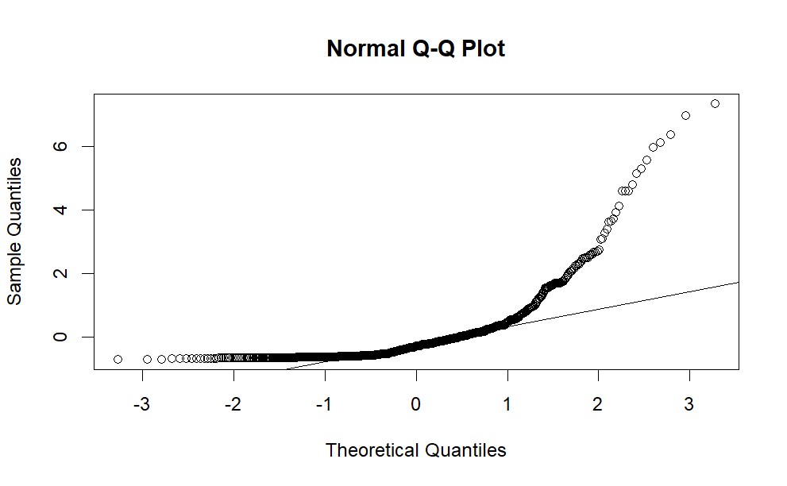

```r
quit
qqgraph(price_scaled_short)
```

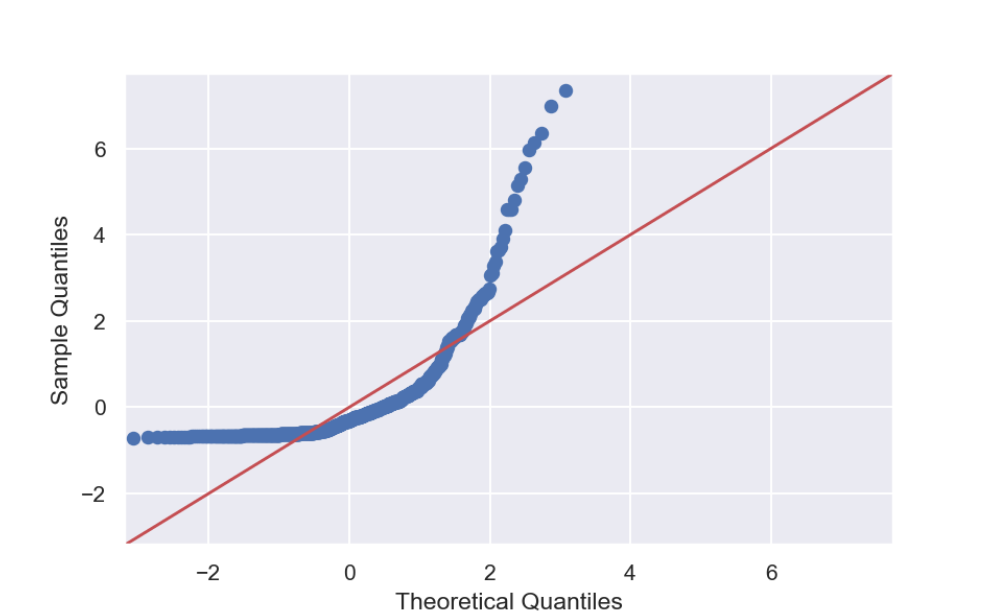

```python
reticulate::repl_python()
#python
plt.clf()
sm.qqplot(price_scaled_short, line='45')
plt.show()
```

График квантилей для большого объёма данных

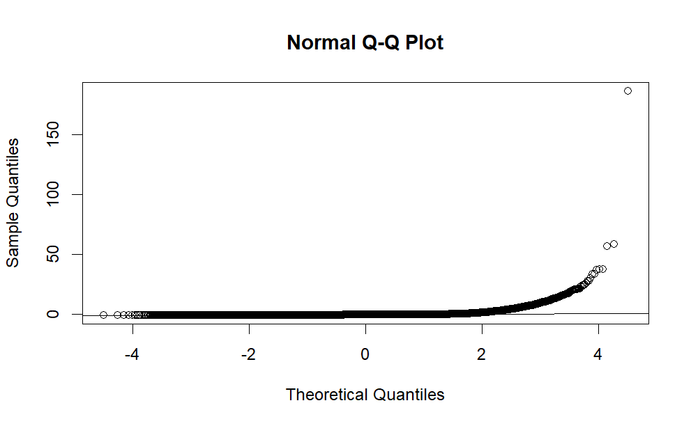

```r
quit
qqgraph(price_scaled)
```

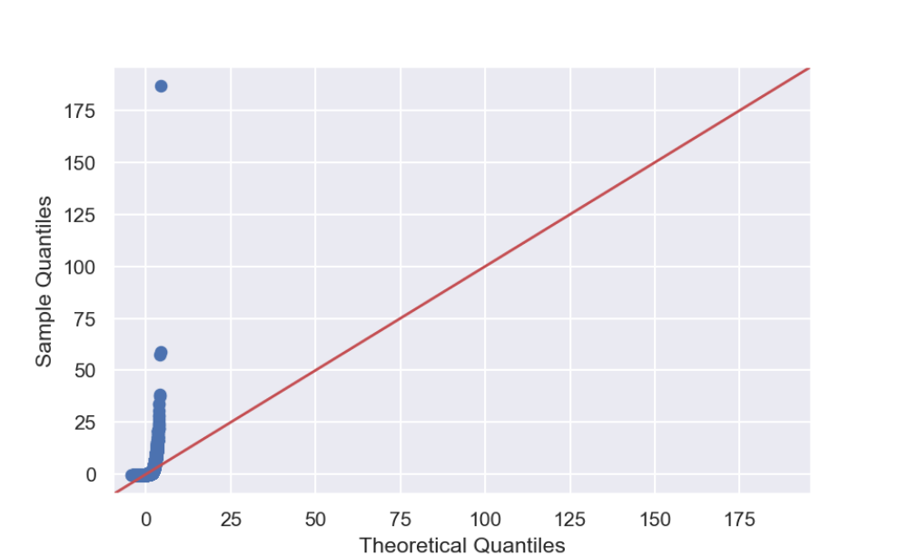

```python
reticulate::repl_python()
#python
plt.clf()
sm.qqplot(price_scaled, line='45')
plt.show()
```

Квантили цены явно не похожи на нормальные. Убедимся на тестах:

```r
quit
ks.test(price_scaled_short, "pnorm")
```

```
    Asymptotic one-sample Kolmogorov-Smirnov test

data:  price_scaled_short
D = 0.24034, p-value < 2.2e-16
alternative hypothesis: two-sided
```

```r
shapiro.test(price_scaled_short)
```

```
    Shapiro-Wilk normality test

data:  price_scaled_short
W = 0.64048, p-value < 2.2e-16
```

```r
ad.test(price_scaled_short)
```

```
    Anderson-Darling normality test

data:  price_scaled_short
A = 93.747, p-value < 2.2e-16
```

```r
cvm.test(price_scaled_short)
```

```
    Cramer-von Mises normality test

data:  price_scaled_short
W = 17.196, p-value = 7.37e-10
```

```r
lillie.test(price_scaled_short)
```

```
    Lilliefors (Kolmogorov-Smirnov) normality test

data:  price_scaled_short
D = 0.24034, p-value < 2.2e-16
```

```python
reticulate::repl_python()
#python
print(kstest(price_scaled_short, 'norm'))
```

[output not shown]

```python
print(cramervonmises(price_scaled_short, 'norm'))
```

[output not shown]

```r
quit
ks.test(price_scaled, "pnorm")
```

```
    Asymptotic one-sample Kolmogorov-Smirnov test

data:  price_scaled
D = 0.3679, p-value < 2.2e-16
alternative hypothesis: two-sided
```

```r
ad.test(price_scaled)
```

```
    Anderson-Darling normality test

data:  price_scaled
A = 34178, p-value < 2.2e-16
```

```r
cvm.test(price_scaled)
```

```
    Cramer-von Mises normality test

data:  price_scaled
W = 6978.1, p-value = 7.37e-10
```

```r
lillie.test(price_scaled)
```

```
    Lilliefors (Kolmogorov-Smirnov) normality test

data:  price_scaled
D = 0.3679, p-value < 2.2e-16
```

```python
reticulate::repl_python()
#python
print(kstest(price_scaled, 'norm'))
print(shapiro(price_scaled))
```

[output not shown]

```
ShapiroResult(statistic=0.20358192920684814, pvalue=0.0)
```

```python
print(anderson(price_scaled))
print(cramervonmises(price_scaled, 'norm'))
```

[output not shown]

```
CramerVonMisesResult(statistic=6978.096692680846, pvalue=0)
```

Во всех тестах p-value крайне маленькое, это означает, что гипотеза о нормальности данных можно отвергнуть. На графиках квантилей хорошо видно, что они являются нелинейными, скорее похожи на квантили показательного распределения.

# **7. Продемонстрировать применение для проверки различных гипотез и различных доверительных уровней 0.9, 0.95, 0.99 следующих критериев:**

## **Критерий Стьюдента**

Проверим, как ведёт себя критерий Стьюдента, если в качестве предполагаемого среднего цены квартир на окраине взять среднее по всей выборке. Квартиры на окраинах составляют 62% всего датасета.

```python
#python
print(df[df.metro=='Outskirts'].shape[0]/df.shape[0])
```

```
0.6249076273423066
```

```r
quit
print(paste('Среднее цены по всей выборке', mean(data$price)))
```

```
[1] "Среднее цены по всей выборке 27241407.8722552"
```

```r
for (conf_level in c(0.9, 0.95, 0.99))
  print(t.test(subset(data, metro=='Outskirts')$price,
               mu = mean(data$price),
               conf.level = conf_level))
```

```
    One Sample t-test

data:  subset(data, metro == "Outskirts")$price
t = -9.3614, df = 94710, p-value < 2.2e-16
alternative hypothesis: true mean is not equal to 27241408
90 percent confidence interval:
 24788614 25521745
sample estimates:
mean of x
 25155180


    One Sample t-test

data:  subset(data, metro == "Outskirts")$price
t = -9.3614, df = 94710, p-value < 2.2e-16
alternative hypothesis: true mean is not equal to 27241408
95 percent confidence interval:
 24718389 25591971
sample estimates:
mean of x
 25155180


    One Sample t-test

data:  subset(data, metro == "Outskirts")$price
t = -9.3614, df = 94710, p-value < 2.2e-16
alternative hypothesis: true mean is not equal to 27241408
99 percent confidence interval:
 24581135 25729225
sample estimates:
mean of x
 25155180
```

Гипотезу отвергаем, хотя средние и похожи.

Теперь используем двусторонний критерий для сравнения средних цен для квартир на Беляево и Первомайской. Их квантили +- похожи на гауссовские, средние равны и их можно считать независимыми, т.к. эти станции расположены очень далеко друг от друга, а значит, критерий Стьюдента можно применять.

```r
print(mean(subset(data, metro==' Beliaevo ')$price))
```

```
[1] 15855090
```

```r
print(mean(subset(data, metro==' Pervomaiskaia ')$price))
```

```
[1] 15881179
```

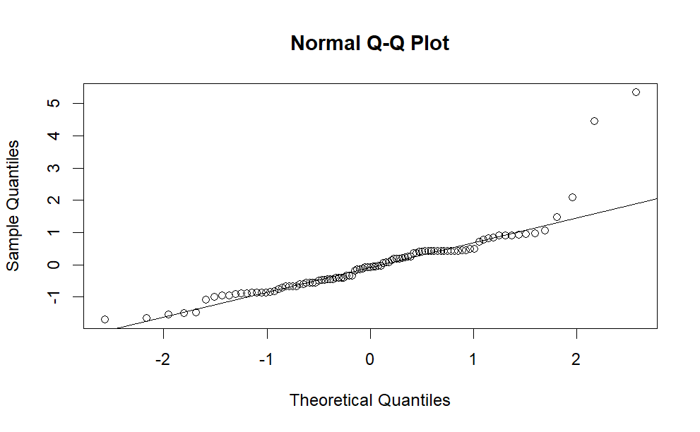

```r
qqgraph(scale(subset(data, metro==' Beliaevo ')$price))
```

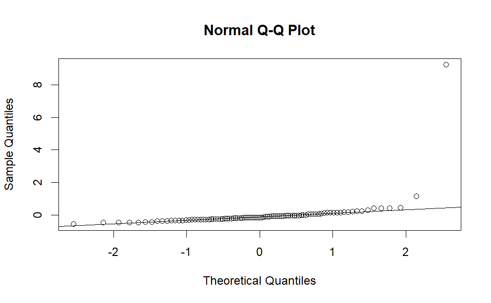

```r
qqgraph(scale(subset(data, metro==' Pervomaiskaia ')$price))
```

```python
reticulate::repl_python()
#python
for conf in [0.9, 0.95, 0.99]:
    print("Доверительный уровень {}\n".format(conf))
    for alt in ['two-sided', 'greater']:
        print(
          ttest(df[df.metro == ' Beliaevo '].price,
                df[df.metro == ' Pervomaiskaia '].price,
                alternative=alt,
                confidence=conf)[['CI{}%'.format(int(100*conf)),
                                  'p-val',
                                  'alternative']])
        print()
```

```
Доверительный уровень 0.9

                                            CI90%     p-val alternative
T-test  [-3660366.8427592046, 3608189.6299863136]  0.990523   two-sided

                             CI90%     p-val alternative
T-test  [-2851041.1806936674, inf]  0.504739     greater

Доверительный уровень 0.95

                            CI95%     p-val alternative
T-test  [-4367451.51, 4315274.29]  0.990523   two-sided

                     CI95%     p-val alternative
T-test  [-3660366.84, inf]  0.504739     greater

Доверительный уровень 0.99

                                          CI99%     p-val alternative
T-test  [-5766936.596025816, 5714759.383252925]  0.990523   two-sided

                            CI99%     p-val alternative
T-test  [-5196898.024987521, inf]  0.504739     greater
```

p-value 0.99, значит выборка хорошо показывает среднюю цену на недвижимость в этих районах.

**Критерий Уилкоксона-Манна-Уитни**

Рассмотрим объекты на тех же станциях. Нулевая гипотеза $H_0$ - распределения цен равны, альтернатива $H_1$ - распределения не равны.

```r
quit
wilcox.test(x = subset(data, metro==' Beliaevo ')$price,
            y = subset(data, metro==' Pervomaiskaia ')$price,
            alternative = 'two.sided',
            exact = FALSE)
```

```
    Wilcoxon rank sum test with continuity correction

data:  subset(data, metro == " Beliaevo ")$price and subset(data, metro == " Pervomaiskaia ")$price
W = 5453, p-value = 0.02735
alternative hypothesis: true location shift is not equal to 0
```

```python
reticulate::repl_python()
#python
print(mannwhitneyu(df[df.metro == ' Beliaevo '].price,
                   df[df.metro == ' Pervomaiskaia '].price,
                   alternative = 'two-sided'))
```

```
MannwhitneyuResult(statistic=5453.0, pvalue=0.027350020330677894)
```

Как видно, p-value мал, значит нельзя утверждать о том, что цены распределены одинакого.

## **Критерий Фишера:**

```r
quit
var.test(subset(data, metro==' Beliaevo ')$price,
         subset(data, metro==' Pervomaiskaia ')$price)
```

```
    F test to compare two variances

data:  subset(data, metro == " Beliaevo ")$price and subset(data, metro == " Pervomaiskaia ")$price
F = 0.13099, num df = 98, denom df = 92, p-value < 2.2e-16
alternative hypothesis: true ratio of variances is not equal to 1
95 percent confidence interval:
 0.08726805 0.19609430
sample estimates:
ratio of variances
         0.1309872
```

Делаем вывод, что дисперсии существенно различаются.

## **Критерий Левене:**

```r
f <- c(rep(1, length(subset(data, metro==' Beliaevo ')$price)),
       rep(2, length(subset(data, metro==' Pervomaiskaia ')$price)))
print(leveneTest(c(subset(data, metro==' Beliaevo ')$price,
                   subset(data, metro==' Pervomaiskaia ')$price),
                 group = f))
```

```
Levene's Test for Homogeneity of Variance (center = median)
       Df F value Pr(>F)
group   1  0.1413 0.7075
      190
```

[output not shown]

```python
reticulate::repl_python()
#python
print(levene(df[df.metro == ' Beliaevo '].price,
             df[df.metro == ' Pervomaiskaia '].price))
```

```
LeveneResult(statistic=0.14125433963557205, pvalue=0.707456489878953)
```

Критерий Левене дал противоположный результат.

## **Критерий Бартлетта:**

```r
quit
print(bartlett.test(c(subset(data, metro==' Beliaevo ')$price,
                      subset(data, metro==' Pervomaiskaia ')$price),
                      g = f))
```

```
    Bartlett test of homogeneity of variances

data:  c(subset(data, metro == " Beliaevo ")$price, subset(data, metro == " Pervomaiskaia ")$price) and f
Bartlett's K-squared = 85.771, df = 1, p-value < 2.2e-16
```

```python
reticulate::repl_python()
#python
print(bartlett(df[df.metro == ' Beliaevo '].price,
               df[df.metro == ' Pervomaiskaia '].price))
```

```
BartlettResult(statistic=85.7705077767415, pvalue=2.0207763158392975e-20)
```

## **Критерий Флигнера-Килина:**

```r
quit
print(fligner.test(c(subset(data, metro==' Beliaevo ')$price,
                     subset(data, metro==' Pervomaiskaia ')$price),
                   g=f))
```

```
    Fligner-Killeen test of homogeneity of variances

data:  c(subset(data, metro == " Beliaevo ")$price, subset(data, metro == " Pervomaiskaia ")$price) and f
Fligner-Killeen:med chi-squared = 3.2484, df = 1, p-value = 0.07149
```

```python
reticulate::repl_python()
#python
print(fligner(df[df.metro == ' Beliaevo '].price,
              df[df.metro == ' Pervomaiskaia '].price))
```

```
FlignerResult(statistic=3.248368669502977, pvalue=0.07149458128466792)
```

# **8. Исследовать корреляционные взаимосвязи в данных с помощью коэффициентов корреляции Пирсона, Спирмена и Кендалла.**

Посмотрим, как цена коррелирует с количеством минут ходьбы до ближайшего метро, площадью объекта и просмотрами объявления.

В этих тестах альтернативной гипотезой является то, что корреляция не равна нулю.

## **Пирсон:**

```python
#python
for feat in ['minutes', 'total_area', 'views']:
    res = pearsonr(df[feat], df['price'])
    print('price / {}:\n corr = {res[0]}, p-value = {res[1]}'
          .format(feat, res=res))
```

```
price / minutes:
 corr = -0.013753030124000889, p-value = 8.585929383686584e-08
price / total_area:
 corr = 0.2102610313765859, p-value = 0.0
price / views:
 corr = 0.03288660148057509, p-value = 1.5108549107052304e-37
```

```r
quit
for (feat in c("minutes", "total_area", "views"))
  print(cor.test(data[feat][, 1], data$price, method='pearson'))
```

```
    Pearson's product-moment correlation

data:  data[feat][, 1] and data$price
t = -5.3546, df = 151558, p-value = 8.586e-08
alternative hypothesis: true correlation is not equal to 0
95 percent confidence interval:
 -0.018786230 -0.008719133
sample estimates:
        cor
-0.01375303


    Pearson's product-moment correlation

data:  data[feat][, 1] and data$price
t = 83.727, df = 151558, p-value < 2.2e-16
alternative hypothesis: true correlation is not equal to 0
95 percent confidence interval:
 0.2054440 0.2150679
sample estimates:
     cor
0.210261


    Pearson's product-moment correlation

data:  data[feat][, 1] and data$price
t = 12.81, df = 151558, p-value < 2.2e-16
alternative hypothesis: true correlation is not equal to 0
95 percent confidence interval:
 0.02785671 0.03791482
sample estimates:
      cor
0.0328866
```

## **Спирмен:**

```python
reticulate::repl_python()
#python
for feat in ['minutes', 'total_area', 'views']:
    res = spearmanr(df[feat], df['price'])
    print('price / {}:\n corr = {res[0]}, p-value = {res[1]}'
          .format(feat, res=res))
```

```
price / minutes:
 corr = 0.06343718503007958, p-value = 6.321791456093398e-135
price / total_area:
 corr = 0.17003823611204524, p-value = 0.0
price / views:
 corr = 0.1178440359482866, p-value = 0.0
```

```r
quit
for (feat in c("minutes", "total_area", "views"))
  print(cor.test(data[feat][, 1], data$price, method='spearman'))
```

```
    Spearman's rank correlation rho

data:  data[feat][, 1] and data$price
S = 5.4342e+14, p-value < 2.2e-16
alternative hypothesis: true rho is not equal to 0
sample estimates:
       rho
0.06343719
```

```
    Spearman's rank correlation rho

data:  data[feat][, 1] and data$price
S = 4.8157e+14, p-value < 2.2e-16
alternative hypothesis: true rho is not equal to 0
sample estimates:
      rho
0.1700382
```

```
    Spearman's rank correlation rho

data:  data[feat][, 1] and data$price
S = 5.1186e+14, p-value < 2.2e-16
alternative hypothesis: true rho is not equal to 0
sample estimates:
     rho
0.117844
```

## **Кендалл:**

```python
reticulate::repl_python()
#python
for feat in ['minutes', 'total_area', 'views']:
    res = kendalltau(df[feat], df['price'])
    print('price / {}:\n corr = {res[0]}, p-value = {res[1]}'
          .format(feat, res=res))
```

```
price / minutes:
 corr = 0.04521955019620875, p-value = 5.20757365861433e-122
price / total_area:
 corr = 0.13220823787484318, p-value = 0.0
price / views:
 corr = 0.07799794748563298, p-value = 0.0
```

Поскольку данные большие, на R используем [аппроксимацию](https://rdrr.io/cran/pcaPP/man/cor.fk.html)

```r
quit
for (feat in c("minutes", "total_area", "views"))
  print(cor.fk(data[feat][, 1], data$price))
```

```
[1] 0.04521955
[1] 0.1322082
[1] 0.07799795
```

Везде p-value мало, значит, что полученные корреляции не противоречат истинным, хотя они и не высокие. Больше всего цена коррелирует с площадью квартиры, хотя о линейной зависимости говорить нельзя.

# **9. Продемонстрировать использование методов хи-квадрат, точного теста Фишера, теста МакНемара, Кохрана-Мантеля-Хензеля.**

Какой район мог бы служить *эталоном*? Т.е. недвижимость в этом районе была бы *похожей* на среднюю по Москве.

Ничего лучше, чем рассмотреть распределение по кол-ву комнат в квартирах, я не придумал.

Предположим, что низ серой ветки является эталоном. p - вектор из частот для разного кол-ва комнат по Москве.

## **Тест** $\chi^2$**:**

```r
p <- table(data$rooms) / length(data$rooms)

tmp <- table(data[data$metro == ' Kakhovskaia ' |
                  data$metro == ' Sevastopolskaia ' |
                  data$metro == ' Uzhnaia ' |
                  data$metro == ' Prazhskaia ' |
                  data$metro == ' Annino ',]$rooms)

chisq.test(tmp / sum(tmp), p=p)
```

```
    Chi-squared test for given probabilities

data:  tmp/sum(tmp)
X-squared = 0.072097, df = 10, p-value = 1
```

```python
reticulate::repl_python()
#python
p = df.rooms.apply(str).value_counts() / df.shape[0]

tmp = df[(df.metro == ' Kakhovskaia ') |
           (df.metro == ' Sevastopolskaia ') |
           (df.metro == ' Uzhnaia ') |
           (df.metro == ' Prazhskaia ') |
           (df.metro == ' Annino ')].rooms.apply(str).value_counts()

for key in df.rooms.apply(str).unique():
  if not key in tmp:
    tmp[key] = 0

print(chisquare(tmp / sum(tmp), p))
```

```
Power_divergenceResult(statistic=0.06203187286982125, pvalue=0.9999999997669107)
```

Данные не противоречат гипотезе. Хотя и наблюдений относительно мало (~150).

## **Точный тест Фишера:**

Проверим однородность данных внутри тех же станций. Для этого рассмотрим двух- и трёхкомнатные квартиры, а станции поделим на две части.

[output not shown]

```r
quit
tmp1 <- table(data[data$metro == ' Kakhovskaia ' |
                   data$metro == ' Sevastopolskaia ',]$rooms)
tmp2 <- table(data[data$metro == ' Uzhnaia ' |
                   data$metro == ' Prazhskaia ' |
                   data$metro == ' Annino ', ]$rooms)

m <- matrix(c(tmp1['2'], tmp1['3'], tmp2['2'], tmp2['3']),
            nrow=2, ncol=2, byrow=TRUE)
print(m)
```

```
     [,1] [,2]
[1,]   26   11
[2,]   31   25
```

```r
print(fisher.test(m))
```

```
    Fisher's Exact Test for Count Data

data:  m
p-value = 0.1931
alternative hypothesis: true odds ratio is not equal to 1
95 percent confidence interval:
 0.7306094 5.1219858
sample estimates:
odds ratio
   1.89305
```

```python
reticulate::repl_python()
#python
tmp1 = df[(df.metro == ' Kakhovskaia ') |
           (df.metro == ' Sevastopolskaia ')].rooms.apply(str).value_counts()

tmp2 = df[(df.metro == ' Uzhnaia ') |
           (df.metro == ' Prazhskaia ') |
           (df.metro == ' Annino ')].rooms.apply(str).value_counts()

m = [[tmp1['2'], tmp1['3']],
     [tmp2['2'], tmp2['3']]]

print(fisher_exact(m))
```

```
SignificanceResult(statistic=1.906158357771261, pvalue=0.19306067951338876)
```

Тут p-value не такой высокий, но тест Фишера подходит для выборок малого объёма, поэтому гипотеза правдоподобна.

## **Тест МакНемара:**

Этот критерий требует бинарных пртзнаков, поэтому немного изменим матрицу.

```r
quit

m1 <- matrix(c(sum(tmp1) - tmp1['3'], tmp1['3'], sum(tmp2) - tmp2['3'], tmp2['3']),
            nrow=2, ncol=2, byrow=TRUE)

print(mcnemar.test(m1))
```

```
    McNemar's Chi-squared test with continuity correction

data:  m1
McNemar's chi-squared = 50.813, df = 1, p-value = 1.016e-12
```

```python
reticulate::repl_python()
#python
m1 = [[sum(tmp1) - tmp1['3'], tmp1['3']],
      [sum(tmp2) - tmp2['3'], tmp2['3']]]

print(mcnemar(m1, exact=False))
```

```
pvalue      1.0158888796646924e-12
statistic   50.81318681318681
```

На этом тесте неудача, но это означает, что маргинальные распределения могут не совпадать.

# **10. Проверить наличие мультиколлинеарности в данных с помощьюю корреляционной матрицы и фактора инфляции дисперсии.**

## **Корреляционная матрица**

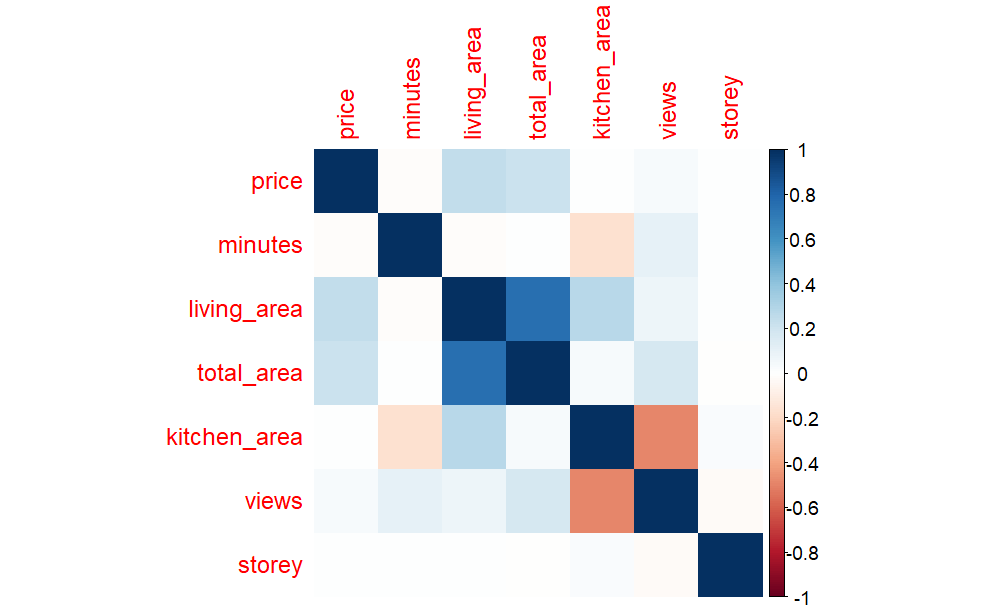

```r
quit
corrplot(cor(data[, c("price", "minutes",
                      "living_area", "total_area", "kitchen_area",
                      "views", "storey")]),
         method="color")
```

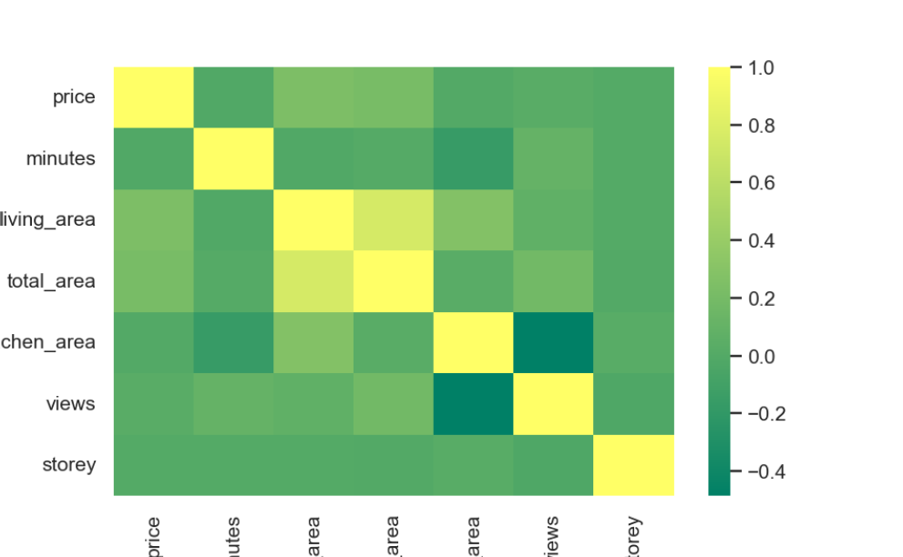

```python
reticulate::repl_python()
#python
plt.clf()
sns.heatmap(df[["price", "minutes",
                "living_area", "total_area", "kitchen_area",
                "views", "storey"]].corr(), cmap='summer')
plt.show()
```

total_area и living_area сильно коррелируют (очев.). Интересно, что kitchen_area слабо связана с total_area и коррелирует в обратную сторону с количеством просмотров.

living_area выкидываем.

## **Фактор инфляции дисперсии:**

```r
quit
model <- lm(price ~ minutes + total_area + kitchen_area + storey, data=data)
print(VIF(model))
```

```
     minutes   total_area kitchen_area       storey
    1.027428     1.001368     1.029360     1.000861
```

```python
reticulate::repl_python()
#python
for fact in ["minutes", "total_area", "kitchen_area", "views", "storey"]:
    print(fact, "/ price VIF = ", variance_inflation_factor(df[["price", fact]], 0))
```

```
minutes / price VIF =  -0.0031521398481905356
total_area / price VIF =  -0.0036277844781549898
kitchen_area / price VIF =  -0.003455031649528997
views / price VIF =  -0.0031525155810180443
storey / price VIF =  -0.0030794958775870866
```

Почему-то получились разные результаты, но в обоих случаях VIF небольшой, это значит, что нет фактора, который бы сильнее остальных коррелировал с ценой.

# **11. Исследовать зависимости в данных с помощью дисперсионного анализа.**

Проверим, зависит ли средняя цена от продавца недвижимости (владелец, агенство и т.д.).

```r
quit
print(summary(aov(price ~ provider, data = data)))
```

```
                Df    Sum Sq   Mean Sq F value Pr(>F)
provider         7 1.051e+19 1.501e+18   285.5 <2e-16 ***
Residuals   151552 7.965e+20 5.256e+15
---
Signif. codes:  0 ‘***’ 0.001 ‘**’ 0.01 ‘*’ 0.05 ‘.’ 0.1 ‘ ’ 1
```

Видим, что p-value маленькое, значит, зависимость есть. В python удобнее рассматривать конкретные пары (aov в R проверяет сразу по всем категориям).

Рассмотрим пары владелец / застройщик и владелец / агенство.

```python
reticulate::repl_python()
#python
print("owner / developer:\n",
      f_oneway(df[df.provider.apply(lambda x: x.strip()) == 'owner'].price,
               df[df.provider.apply(lambda x: x.strip()) == 'developer'].price))
```

```
owner / developer:
 F_onewayResult(statistic=0.05337962370423846, pvalue=0.8172840648312041)
```

```python
print("owner / agency:\n",
      f_oneway(df[df.provider.apply(lambda x: x.strip()) == 'owner'].price,
               df[df.provider.apply(lambda x: x.strip()) == 'agency'].price))
```

```
owner / agency:
 F_onewayResult(statistic=243.9627815269836, pvalue=6.5258812139461e-55)
```

Видно, что в среднем цена у владельцев и застройщиков одинакова, а у агенств отличается.

# **12. Подогнать регрессионные модели (в том числе, нелинейные) к данным, а также оценить качество подобной аппроксимации.**

Рассматриваю линейную модель с $L^1$-регуляризацией.

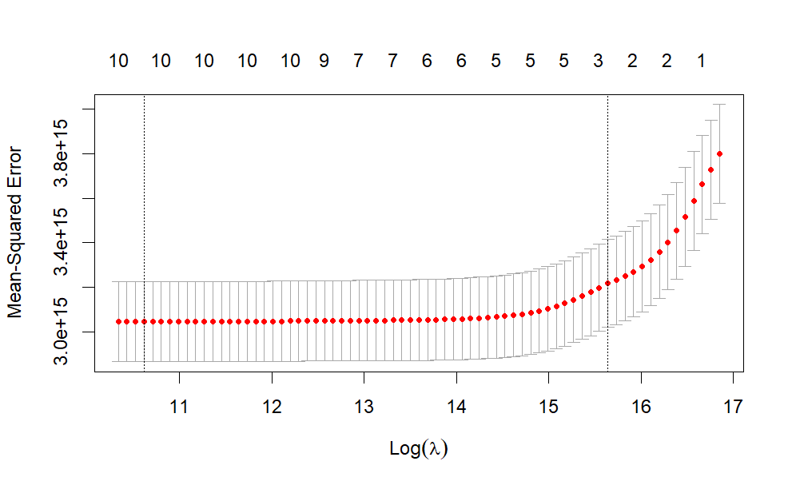

```r
quit

index <- c('metro', 'minutes', 'way', 'provider', 'storey', 'storeys',
           'rooms', 'total_area', 'living_area', 'kitchen_area')

sample <- sample(c(TRUE, FALSE), nrow(data), replace=TRUE, prob=c(0.7,0.3))
train  <- data[sample, ]
test   <- data[!sample, ]

cv_model <- cv.glmnet(data.matrix(train[,index]),
                      data.matrix(train$price),
                      alpha = 1)

best_lambda <- cv_model$lambda.min

plot(cv_model)
```

```r
best_model <- glmnet(data.matrix(train[,index]),
                     data.matrix(train$price),
                     alpha=1,
                     lambda=best_lambda)

pred <- predict(best_model, s=best_lambda, newx=data.matrix(test[,index]))

print(paste("test RMSE = ", sqrt(mean((pred - test$price)**2))))
```

```
[1] "test RMSE =  89243597.4803707"
```

```r
print(coef(best_model))
```

```
11 x 1 sparse Matrix of class "dgCMatrix"
                        s0
(Intercept)  -83143621.501
metro           -89339.959
minutes        -103726.303
way           12911860.970
provider      -4247613.228
storey           87107.784
storeys          -1038.412
rooms         14355854.823
total_area       39336.223
living_area    1275676.572
kitchen_area    -23830.775
```

Получилась очень плохая оценка. Попробую отмасштабировать данные.

```python
reticulate::repl_python()
#python

sc = StandardScaler()

data_sc = df.drop("views", axis=1)
data_sc.loc[:, ~data_sc.columns.isin(["metro", "way", "provider", "rooms"])] = sc.fit_transform(
  data_sc.drop(["metro", "way", "provider", "rooms"], axis=1))

data_sc.loc[:,["metro", "way", "provider", "rooms"]].apply(str)
data_sc = pd.get_dummies(data_sc, columns=["metro", "way", "provider", "rooms"])

X_train, X_test, y_train, y_test = train_test_split(data_sc.drop(["price"], axis=1).to_numpy(),
                                                    data_sc.price.to_numpy(),
                                                    test_size=0.3)
```

```python
#python

model = LassoCV(cv=5)
model.fit(X_train, y_train)
```

```
LassoCV(cv=5)
```

```python
err = np.sqrt(np.mean((model.predict(X_test) - y_test)**2))

print("test RMSE (scaled):", err)
```

[output not shown]

Немного получше. Попробую бустинг с метрикой среднего абсолютного значения.

```python
#python

model = CatBoostRegressor(iterations=2000, verbose=1000, loss_function="MAE")

model.fit(X_train, y_train)
```

```
0:  learn: 0.2423279    total: 174ms    remaining: 5m 47s
1000:   learn: 0.1547486    total: 20.3s    remaining: 20.3s
1999:   learn: 0.1426801    total: 40.4s    remaining: 0us
<catboost.core.CatBoostRegressor object at 0x0000025B82A9A2E0>
```

```python
err = mean_absolute_error(pred, y_test)

print("test MAE (scaled):", err)
```

[output not shown]

Эта оценка намного лучше, но всё равно ошибка достаточно большая, хотя данных много. Предположу, что недвижимость в Москве очень разнородна, поэтому простые модели не вполне справляются с прогнозированием цены.